# Question C, using elasticnet

```r
library
```

[output not shown]

[output cut: 330 more lines]

[output not shown]

```r
#install.packages("caret", dep = TRUE)
library(lattice)
library(ggplot2)
library(data.table)
library(caret)
library(glmnet)
library(MASS)
library(glasso)
library(sAIC)
library(car)
```

```r
aida = fread("../aida_abs.csv")
```

```
|--------------------------------------------------|
|==================================================|
|--------------------------------------------------|
|==================================================|
```

```r
# Make the operator
'%!in%' <- function(x,y)!('%in%'(x,y))

# Add new empty column
aida$Failed <- NULL

# For each 'Legal status' which contains 'Active' substring fill in new column 'No' else 'Yes'
act_vector <- c('Active','Active (default of payments)','Active (receivership)')
aida[aida$Legal.status %in% act_vector,'Failed'] <- 0
aida[aida$Legal.status %!in% act_vector,'Failed'] <- 1

aida[is.na(aida$Failed), ]
```

| Year | Incorporation.year | Company.name | File | Tax.code.number | ATECO.2007code | Legal.form | Legal.status | Province | Comune.ISTAT.code | Region | Banks/turnover | Cash.Flowth | Cost.of.debit | Current.liabilities/Tot.ass | Current.ratio | Debt/EBITDA.ratio | Debt/equity.ratio | EBITDA/Vendite | EBITDAth | Interest/Turnover | Leverage | Liquidity.ratio | Net.financial.positionth | Net.working.capitalth | Number.of.employees | Profit.(loss)th | ROA | ROE | ROI | … |
| --- | --- | --- | --- | --- | --- | --- | --- | --- | --- | --- | --- | --- | --- | --- | --- | --- | --- | --- | --- | --- | --- | --- | --- | --- | --- | --- | --- | --- | --- | --- |

```r
aida$Failed <- as.factor(aida$Failed)

aida <- na.omit(aida)
drops <- c('Company.name','File','Tax.code.number','Legal.form','Legal.status','Comune.ISTAT.code','Region','Province')
aida <- subset(aida, select = -c(Company.name,ATECO.2007code,File,Tax.code.number,Legal.form,Legal.status,Comune.ISTAT.code,Region,Province))
```

Get 2014 and 2015 data because the distribution considering Failed is balanced

```r
data = na.omit(aida[aida$Year %in% c(2014,2015)])
table(data$Failed)
```

```
    0     1
20558 21053
```

1. Un problema dei modelli lineari è l’alta correlazione tra le variabili indipendenti, prima di costruire il regresore logistico si cerca di escludere le variabili con correlazione > di una certa soglia
- In caso di correlazione tra due variabili, si elimina quella con VIF (Variance Inflation Factor) maggiore
- In alternativa, il metodo findCorrelation della libreria caret, restituisce direttamente le variabili da escludere sulla base della mean absolute correlation (“https://www.rdocumentation.org/packages/caret/versions/6.0-88/topics/findCorrelation”), oltre che le coppie di variabili che superano la soglia prestabilita

```r
corr.matrix=cor(subset(data, select = -c(Failed)))
#corr.matrix[abs(corr.matrix) < 0.8] = NA
#View(corr.matrix)
to.remove = findCorrelation(corr.matrix, cutoff = .8, verbose = TRUE, names=TRUE)
```

```
Compare row 17  and column  25 with corr  0.993
  Means:  0.232 vs 0.119 so flagging column 17
Compare row 25  and column  4 with corr  0.906
  Means:  0.199 vs 0.111 so flagging column 25
Compare row 4  and column  15 with corr  0.884
  Means:  0.167 vs 0.104 so flagging column 4
Compare row 15  and column  18 with corr  0.931
  Means:  0.125 vs 0.099 so flagging column 15
Compare row 18  and column  16 with corr  0.928
  Means:  0.089 vs 0.099 so flagging column 16
Compare row 21  and column  19 with corr  0.855
  Means:  0.177 vs 0.096 so flagging column 21
Compare row 14  and column  7 with corr  0.801
  Means:  0.125 vs 0.09 so flagging column 14
All correlations <= 0.8
```

```r
to.remove
```

```
[1] "Number.of.employees"      "Total.assetsth"           "Cash.Flowth"              "Net.financial.positionth"
[5] "Net.working.capitalth"    "ROI"                      "Liquidity.ratio"
```

```r
#data = subset(data, select = -c(Cash.Flowth, EBITDAth, Total.assetsth, ROA, Liquidity.ratio))
```

```r
cat(colnames(data)[17], "-", colnames(data)[25], "\n") #remove Total.assetsth
```

```
Number.of.employees - Total.assetsth
```

```r
cat(colnames(data)[25], "-", colnames(data)[4], "\n") #remove Total.assetsth
```

```
Total.assetsth - Cash.Flowth
```

```r
cat(colnames(data)[4], "-", colnames(data)[15], "\n") #remove Net.financial.positionth
```

```
Cash.Flowth - Net.financial.positionth
```

```r
cat(colnames(data)[15], "-", colnames(data)[18], "\n") #remove Net.financial.positionth
```

```
Net.financial.positionth - Profit.(loss)th
```

```r
cat(colnames(data)[18], "-", colnames(data)[16], "\n") #remove Net.working.capitalth
```

```
Profit.(loss)th - Net.working.capitalth
```

```r
cat(colnames(data)[19], "-", colnames(data)[21], "\n") #remove ROA
```

```
ROA - ROI
```

```r
cat(colnames(data)[14], "-", colnames(data)[7], "\n") #remove Current.ratio
```

```
Liquidity.ratio - Current.ratio
```

Si guarda al valore di VIF, le variabili con valore alto devono essere rimosse

```r
noresampling = trainControl(method="none")

lr.fit = glm(Failed ~ ., data = na.omit(data), family=binomial("logit"))
```

```
glm.fit: fitted probabilities numerically 0 or 1 occurred
```

```r
sort(vif(lr.fit))
```

```
            `Debt/EBITDA.ratio`                            Year              Incorporation.year   `Current.liabilities/Tot.ass`
                       1.004676                        1.007785                        1.116365                        1.461475
                            ROE `Total.assets.turnover.(times)`                        Leverage             `Debt/equity.ratio`
                       1.517749                        1.549564                        1.565824                        1.626582
                 Solvency.ratio                   Cost.of.debit                `EBITDA/Vendite`                 Liquidity.ratio
                       1.646105                        2.156956                        2.324675                        2.985684
                            ROS                   Current.ratio                `Banks/turnover`             `Interest/Turnover`
                       3.424123                        3.438520                        3.765374                        4.160622
                            ROI                             ROA               `Profit.(loss)th`                        EBITDAth
                       4.631631                        5.379734                        6.854998                       11.248584
            Number.of.employees                     Cash.Flowth                  Total.assetsth           Net.working.capitalth
                      25.634466                       29.212783                      122.649427                      268.897392
       Net.financial.positionth
                     524.603029
```

Remove useless columns

```r
data <- subset(data, select = -c(Total.assetsth, Net.financial.positionth, Net.working.capitalth, ROA, Current.ratio, Year))
```

Partitioning dataset

```r
set.seed(42)
trainIndex <- createDataPartition(data$Failed, p = .7,
                                  list = FALSE,
                                  times = 1)

aidaTrain <- data[ trainIndex,]
aidaTest  <- data[-trainIndex,]

aidaTest2013 = aida[aida$Year %in% c(2013)]
aidaTest2013 = na.omit(aidaTest2013)
aidaTest2013 <- subset(aidaTest2013, select = -c(Total.assetsth, Net.financial.positionth, Net.working.capitalth, ROA, Current.ratio, Year))

table(aidaTrain$Failed)
```

```
    0     1
14391 14738
```

Elastic Net Regularization using glmnet

```r
x <- aidaTrain[, 1:(ncol(aidaTrain)-1)]
y <- aidaTrain$Failed
elasticFit <- cv.glmnet(data.matrix(x), y, family = "binomial", type.measure = 'mse', nfolds = 5, resample.seed = NULL) #returns the best model using CV
```

```r
coef(elasticFit, s = "lambda.min")
```

```
20 x 1 sparse Matrix of class "dgCMatrix"
                                         s1
(Intercept)                    2.889833e+01
Incorporation.year            -1.475274e-02
Banks/turnover                 1.696265e-03
Cash.Flowth                    8.206407e-08
Cost.of.debit                 -8.399533e-03
Current.liabilities/Tot.ass    5.571770e-01
Debt/EBITDA.ratio              .
Debt/equity.ratio              3.335792e-03
EBITDA/Vendite                -3.845259e-03
EBITDAth                       1.741064e-06
Interest/Turnover              2.878030e-02
Leverage                       2.249565e-04
Liquidity.ratio                3.971960e-02
Number.of.employees            4.574479e-04
Profit.(loss)th                6.456769e-06
ROE                           -2.276843e-03
ROI                           -1.682615e-03
ROS                           -8.226338e-03
Solvency.ratio                -2.275352e-03
Total.assets.turnover.(times)  2.113802e-01
```

lambda.min is the value of lambda that gives the minimum mean cross-validated error lambda.1se is the value of lambda that gives the most regularized model

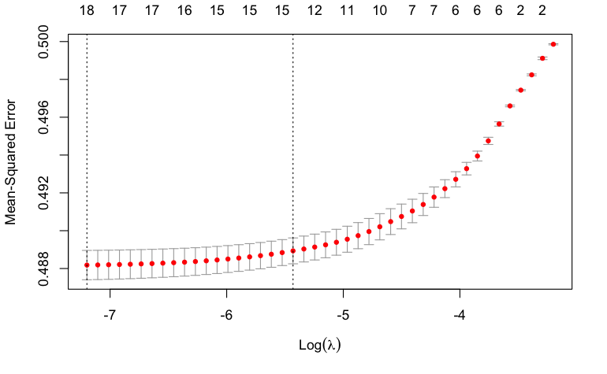

```r
plot(elasticFit)
```

Using LAMBDA.MIN (best)

```r
x.test <- aidaTest[, 1:(ncol(aidaTest)-1)]
y.test <- aidaTest$Failed

# predicted confidence on validation set
elas.pred = predict(elasticFit, newx = data.matrix(x.test), type="class", s = "lambda.min")
elas.prob = predict(elasticFit, newx = data.matrix(x.test), type="response", s = "lambda.min") #as predict proba
# built-in metrics
confusionMatrix(factor(elas.pred), factor(y.test), positive="1", mode = "prec_recall")
```

```
Confusion Matrix and Statistics

          Reference
Prediction    0    1
         0 3504 2670
         1 2663 3645

               Accuracy : 0.5727
                 95% CI : (0.564, 0.5814)
    No Information Rate : 0.5059
    P-Value [Acc > NIR] : <2e-16

                  Kappa : 0.1454

 Mcnemar's Test P-Value : 0.9345

              Precision : 0.5778
                 Recall : 0.5772
                     F1 : 0.5775
             Prevalence : 0.5059
         Detection Rate : 0.2920
   Detection Prevalence : 0.5054
      Balanced Accuracy : 0.5727

       'Positive' Class : 1
```

0,5 is the best cutoff to use, so we’re not modifying it

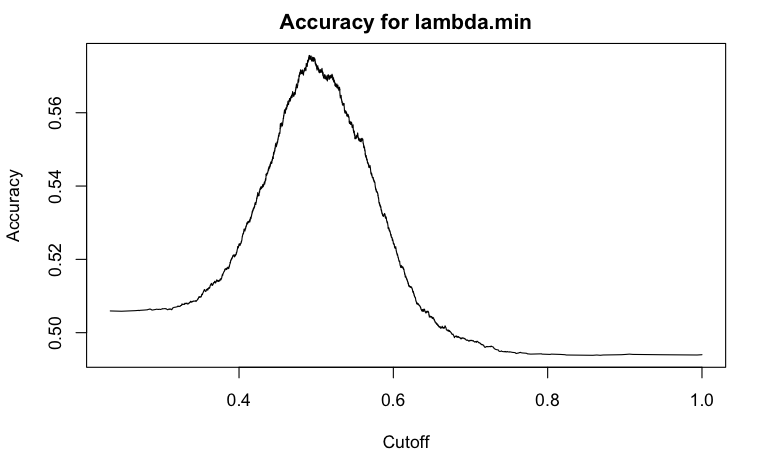

```r
# using ROCR for metrics at cutoff
library(ROCR)
elas.prediction = prediction(elas.prob, aidaTest$Failed)
# acc at cutoff
elas.acc = performance(elas.prediction, "acc"); plot(elas.acc, main = "Accuracy for lambda.min")
```

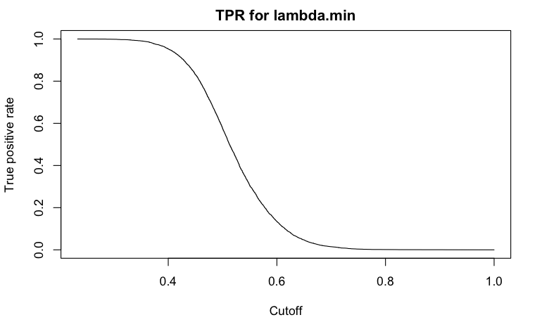

```r
# tpr (recall) at cutoff
elas.tpr = performance(elas.prediction, "tpr"); plot(elas.tpr, main = "TPR for lambda.min")
```

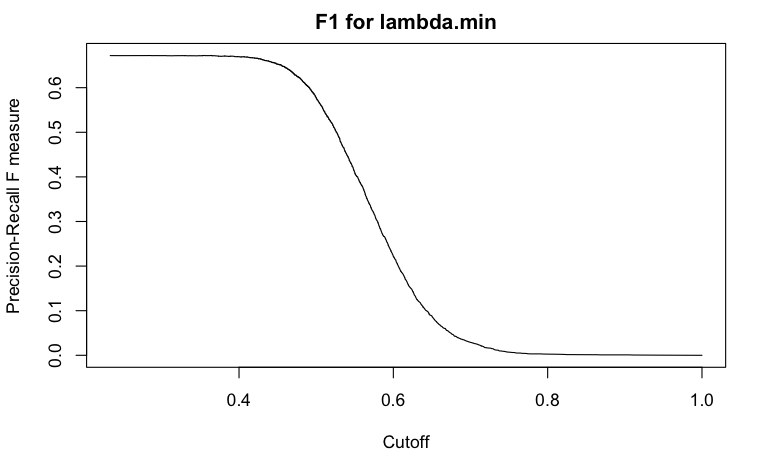

```r
# f1 at cutoff
elas.f1 = performance(elas.prediction, "f"); plot(elas.f1, main = "F1 for lambda.min")
```

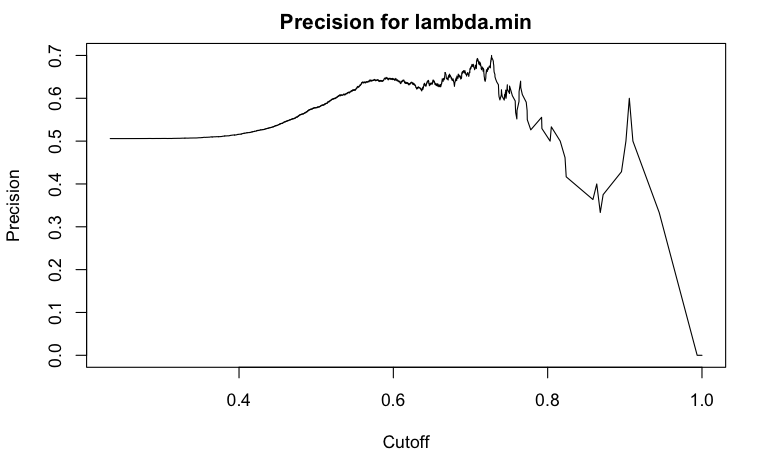

```r
# precision at cutoff
elas.prec = performance(elas.prediction, "prec"); plot(elas.prec, main = "Precision for lambda.min")
```

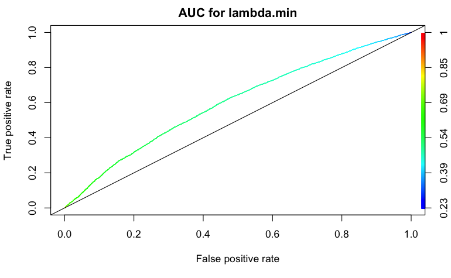

```r
# roc curve
elas.roc = performance(elas.prediction, "tpr", "fpr")
plot(elas.roc, colorize=T, main = "AUC for lambda.min"); abline(a=0, b= 1)
```

```r
cat("AUC value: ", performance(elas.prediction, "auc")@y.values[[1]])
```

```
AUC value:  0.5992636
```

Using LAMBDA.1SE

```r
# predicted confidence on validation set
elas.pred.1se = predict(elasticFit, newx = data.matrix(x.test), type="class", s = "lambda.1se")
elas.prob.1se = predict(elasticFit, newx = data.matrix(x.test), type="response", s = "lambda.1se") #as predict proba
# built-in metrics
confusionMatrix(factor(elas.pred.1se), factor(y.test), positive="1", mode = "prec_recall")
```

```
Confusion Matrix and Statistics

          Reference
Prediction    0    1
         0 3466 2671
         1 2701 3644

               Accuracy : 0.5696
                 95% CI : (0.5609, 0.5783)
    No Information Rate : 0.5059
    P-Value [Acc > NIR] : <2e-16

                  Kappa : 0.1391

 Mcnemar's Test P-Value : 0.6924

              Precision : 0.5743
                 Recall : 0.5770
                     F1 : 0.5757
             Prevalence : 0.5059
         Detection Rate : 0.2919
   Detection Prevalence : 0.5083
      Balanced Accuracy : 0.5695

       'Positive' Class : 1
```

Best cutoff still is 0,5

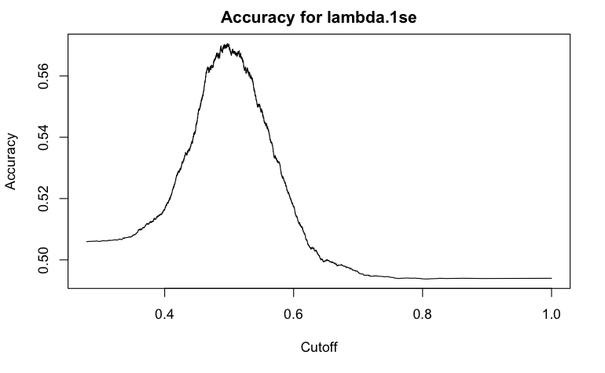

```r
# using ROCR for metrics at cutoff
library(ROCR)
elas.prediction.1se = prediction(elas.prob.1se, aidaTest$Failed)
# acc at cutoff
elas.acc.1se = performance(elas.prediction.1se, "acc"); plot(elas.acc.1se, main = "Accuracy for lambda.1se")
```

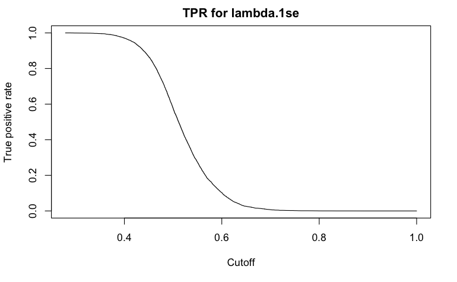

```r
# tpr (recall) at cutoff
elas.tpr.1se = performance(elas.prediction.1se, "tpr"); plot(elas.tpr.1se, main = "TPR for lambda.1se")
```

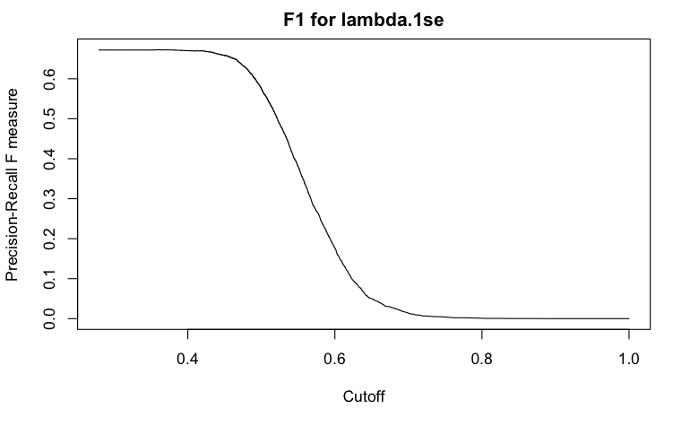

```r
# f1 at cutoff
elas.f1.1se = performance(elas.prediction.1se, "f"); plot(elas.f1.1se, main = "F1 for lambda.1se")
```

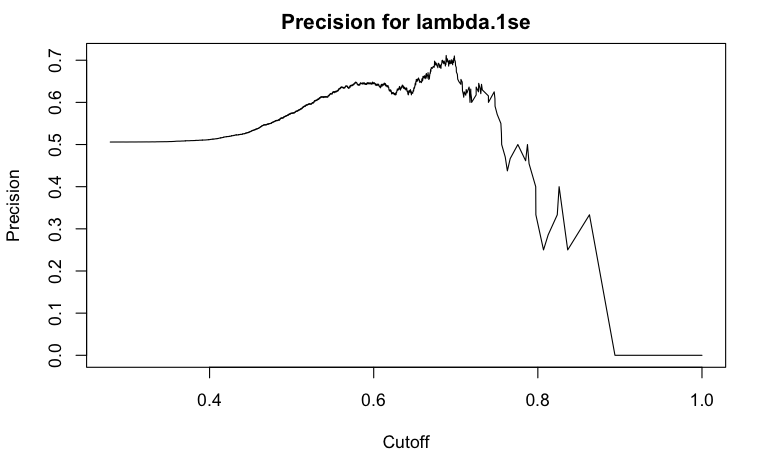

```r
# precision at cutoff
elas.prec.1se = performance(elas.prediction.1se, "prec"); plot(elas.prec.1se, main = "Precision for lambda.1se")
```

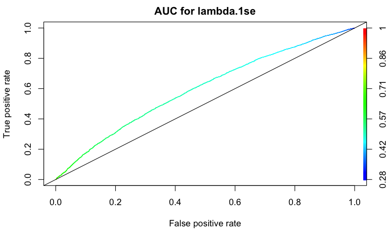

```r
# roc curve
elas.roc.1se = performance(elas.prediction.1se, "tpr", "fpr")
plot(elas.roc.1se, colorize=T, main = "AUC for lambda.1se"); abline(a=0, b= 1)
```

```r
cat("AUC value: ", performance(elas.prediction.1se, "auc")@y.values[[1]])
```

```
AUC value:  0.5961411
```

Predict whether a company failed on 2013, using the model trained on the years 2014-2015 (using lambda.min)

```r
x.2013.test <- aidaTest2013[, 1:(ncol(aidaTest2013)-1)]
y.2013.test <- aidaTest2013$Failed

# predicted confidence on validation set
elas.2013.pred = predict(elasticFit, newx = data.matrix(x.2013.test), type="class", s = "lambda.min")
elas.2013.prob = predict(elasticFit, newx = data.matrix(x.2013.test), type="response", s = "lambda.min") #as predict proba
# built-in metrics
confusionMatrix(factor(elas.2013.pred), factor(y.2013.test), positive="1", mode = "prec_recall")
```

```
Confusion Matrix and Statistics

          Reference
Prediction    0    1
         0 3524 4895
         1 3135 8191

               Accuracy : 0.5933
                 95% CI : (0.5864, 0.6002)
    No Information Rate : 0.6628
    P-Value [Acc > NIR] : 1

                  Kappa : 0.1457

 Mcnemar's Test P-Value : <2e-16

              Precision : 0.7232
                 Recall : 0.6259
                     F1 : 0.6711
             Prevalence : 0.6628
         Detection Rate : 0.4148
   Detection Prevalence : 0.5736
      Balanced Accuracy : 0.5776

       'Positive' Class : 1
```

Calibration plot

```r
cal_data2013 = calibration(aidaTest2013$Failed ~ elas.2013.prob, class="1")
cal_data = calibration(aidaTest$Failed ~ elas.prob, class="1")

plot(cal_data$data$midpoint, cal_data$data$Percent,col="blue", type="o", xlab="Bin Midpoint", ylab="Observed Event Percentage", ylim=c(0,100))

points(cal_data2013$data$midpoint, cal_data2013$data$Percent, col="red", pch="*")
```

```r
lines(cal_data2013$data$midpoint, cal_data2013$data$Percent, col="red")

#Perfettamente calibrato
abline(a=0, b=1, lwd=0.5, lty=2)
```

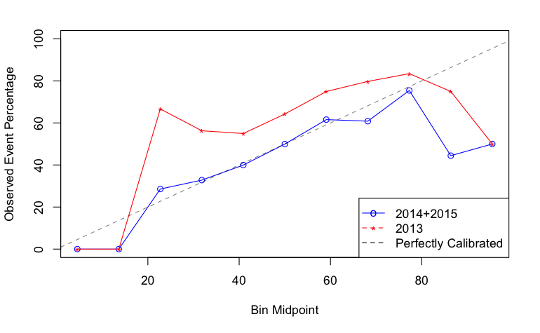

```r
legend("bottomright", legend=c("2014+2015","2013", "Perfectly Calibrated"),
       col=c("blue","red", "black"),
        pch=c("o","*",""),lty=c(1,2,2))
```

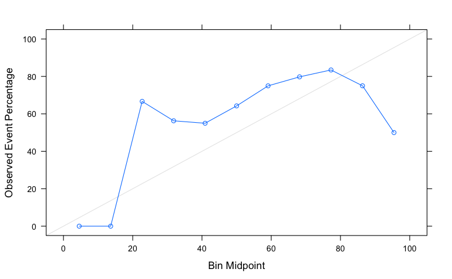

```r
#Plot separati
xyplot(cal_data2013)
```

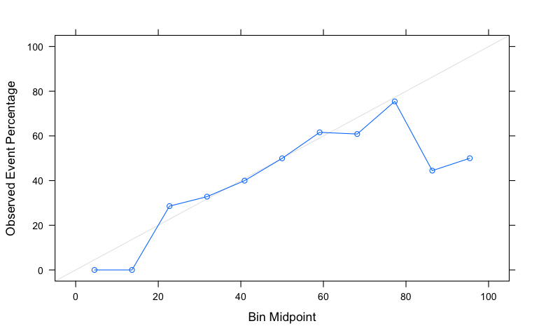

```r
xyplot(cal_data)
```

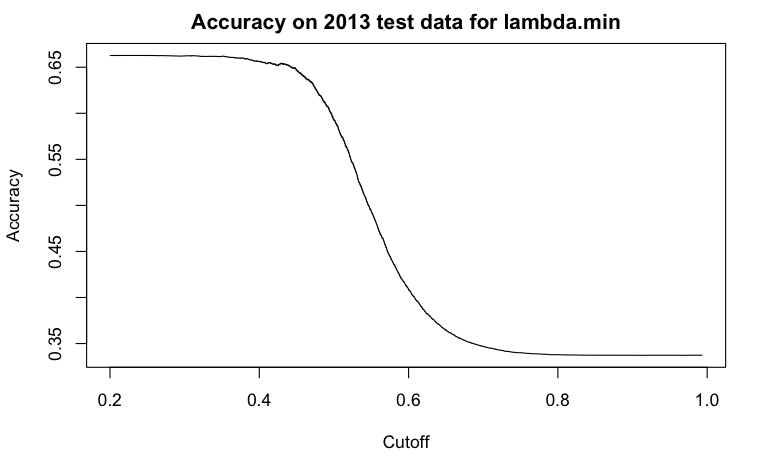

```r
# using ROCR for metrics at cutoff
library(ROCR)
elas.2013.prediction = prediction(elas.2013.prob, aidaTest2013$Failed)
# acc at cutoff
elas.2013.acc = performance(elas.2013.prediction, "acc"); plot(elas.2013.acc, main = "Accuracy on 2013 test data for lambda.min")
```

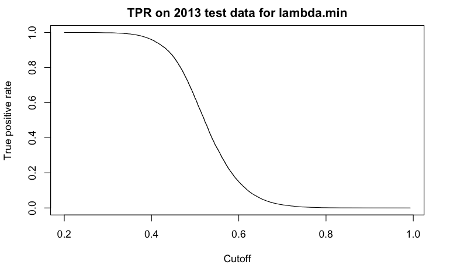

```r
# tpr (recall) at cutoff
elas.2013.tpr = performance(elas.2013.prediction, "tpr"); plot(elas.2013.tpr, main = "TPR on 2013 test data for lambda.min")
```

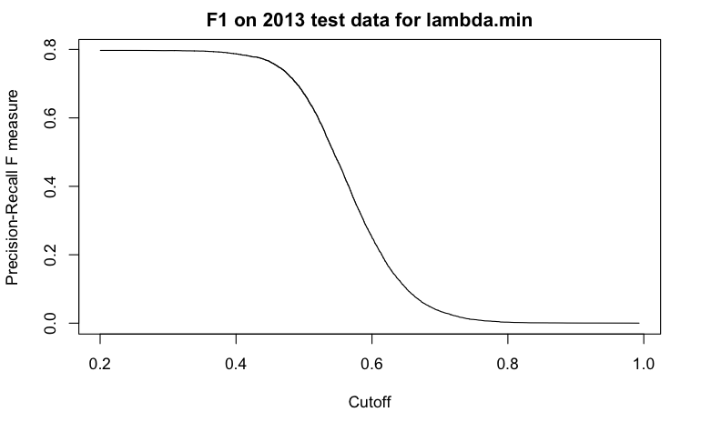

```r
# f1 at cutoff
elas.2013.f1 = performance(elas.2013.prediction, "f"); plot(elas.2013.f1, main = "F1 on 2013 test data for lambda.min")
```

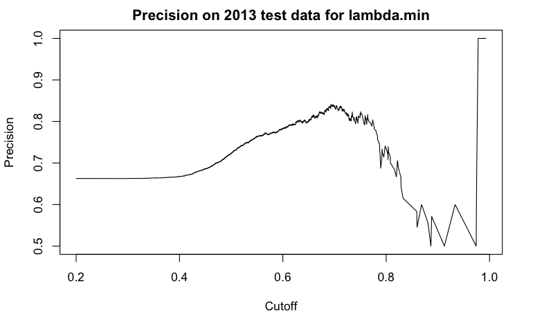

```r
# precision at cutoff
elas.2013.prec = performance(elas.2013.prediction, "prec"); plot(elas.2013.prec, main = "Precision on 2013 test data for lambda.min")
```

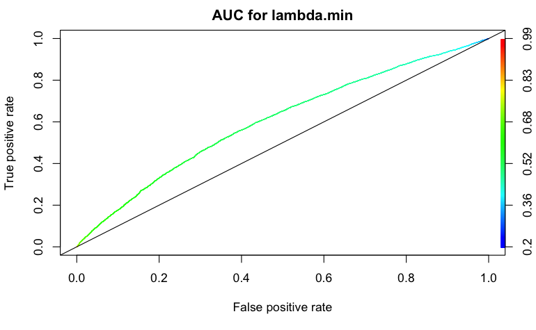

```r
# roc curve
elas.2013.roc = performance(elas.2013.prediction, "tpr", "fpr")
plot(elas.2013.roc, colorize=T, main = "AUC for lambda.min"); abline(a=0, b= 1)
```

```r
cat("AUC value: ", performance(elas.2013.prediction, "auc")@y.values[[1]])
```

```
AUC value:  0.6042012
```

```r
x.2013.test <- aidaTest2013[, 1:(ncol(aidaTest2013)-1)]
y.2013.test <- aidaTest2013$Failed

# predicted confidence on validation set
elas.2013.pred.1se = predict(elasticFit, newx = data.matrix(x.2013.test), type="class", s = "lambda.1se")
elas.2013.prob.1se = predict(elasticFit, newx = data.matrix(x.2013.test), type="response", s = "lambda.1se") #as predict proba
# built-in metrics
confusionMatrix(factor(elas.2013.pred), factor(y.2013.test), positive="1", mode = "prec_recall")
```

```
Confusion Matrix and Statistics

          Reference
Prediction    0    1
         0 3524 4895
         1 3135 8191

               Accuracy : 0.5933
                 95% CI : (0.5864, 0.6002)
    No Information Rate : 0.6628
    P-Value [Acc > NIR] : 1

                  Kappa : 0.1457

 Mcnemar's Test P-Value : <2e-16

              Precision : 0.7232
                 Recall : 0.6259
                     F1 : 0.6711
             Prevalence : 0.6628
         Detection Rate : 0.4148
   Detection Prevalence : 0.5736
      Balanced Accuracy : 0.5776

       'Positive' Class : 1
```

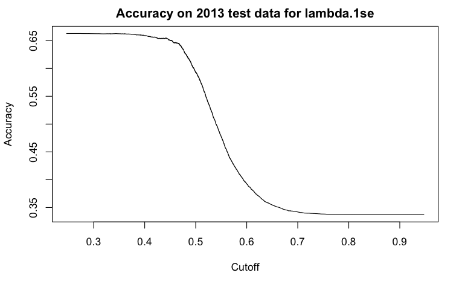

```r
# using ROCR for metrics at cutoff
library(ROCR)
elas.2013.prediction = prediction(elas.2013.prob.1se, aidaTest2013$Failed)
# acc at cutoff
elas.2013.acc = performance(elas.2013.prediction, "acc"); plot(elas.2013.acc, main = "Accuracy on 2013 test data for lambda.1se")
```

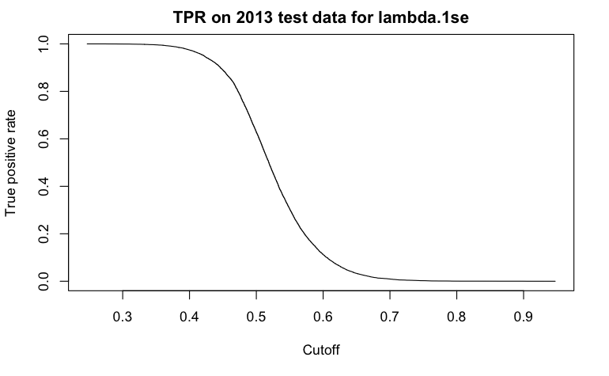

```r
# tpr (recall) at cutoff
elas.2013.tpr = performance(elas.2013.prediction, "tpr"); plot(elas.2013.tpr, main = "TPR on 2013 test data for lambda.1se")
```

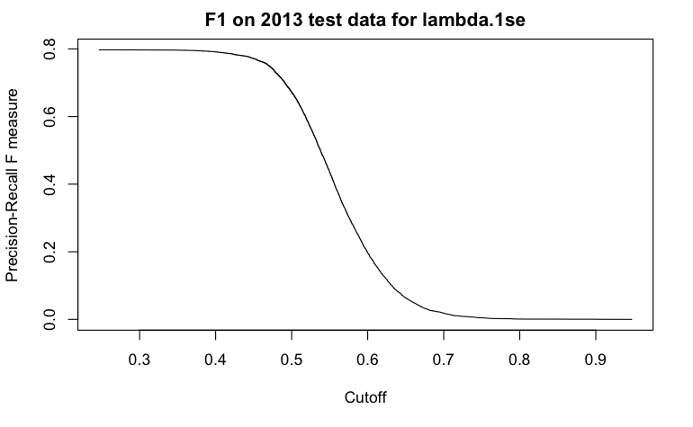

```r
# f1 at cutoff
elas.2013.f1 = performance(elas.2013.prediction, "f"); plot(elas.2013.f1, main = "F1 on 2013 test data for lambda.1se")
```

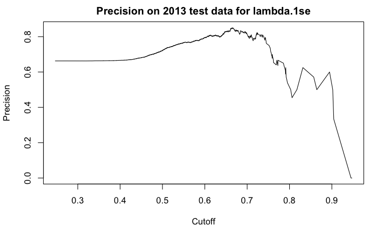

```r
# precision at cutoff
elas.2013.prec = performance(elas.2013.prediction, "prec"); plot(elas.2013.prec, main = "Precision on 2013 test data for lambda.1se")
```

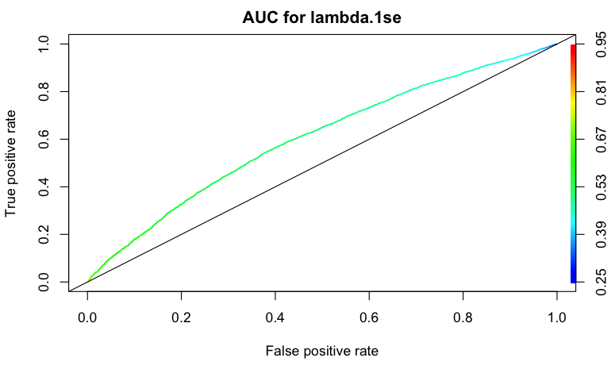

```r
# roc curve
elas.2013.roc = performance(elas.2013.prediction, "tpr", "fpr")
plot(elas.2013.roc, colorize=T, main = "AUC for lambda.1se"); abline(a=0, b= 1)
```

```r
cat("AUC value: ", performance(elas.2013.prediction, "auc")@y.values[[1]])
```

```
AUC value:  0.6045065
```

```r
library(pROC)
par(pty="s")
roc(aidaTest2013$Failed, elas.2013.prob.1se, plot=TRUE, legacy.axes=TRUE,
      xlab="False Positive Rate", ylab="True Positive Rate", print.auc=TRUE, col="red")
```

```
Deprecated use a matrix as predictor. Unexpected results may be produced, please pass a numeric vector.Setting direction: controls < cases
```

```
Call:
roc.default(response = aidaTest2013$Failed, predictor = elas.2013.prob.1se,     plot = TRUE, legacy.axes = TRUE, xlab = "False Positive Rate",     ylab = "True Positive Rate", print.auc = TRUE, col = "red")

Data: elas.2013.prob.1se in 6659 controls (aidaTest2013$Failed 0) < 13086 cases (aidaTest2013$Failed 1).
Area under the curve: 0.6045
```

```r
roc(aidaTest$Failed, elas.prob.1se, plot=TRUE, legacy.axes=TRUE, add=TRUE, col="blue",
      xlab="False Positive Rate", ylab="True Positive Rate", print.auc=TRUE, print.auc.y=0.45)
```

```
Deprecated use a matrix as predictor. Unexpected results may be produced, please pass a numeric vector.Setting direction: controls < cases
```

```
Call:
roc.default(response = aidaTest$Failed, predictor = elas.prob.1se,     plot = TRUE, legacy.axes = TRUE, add = TRUE, col = "blue",     xlab = "False Positive Rate", ylab = "True Positive Rate",     print.auc = TRUE, print.auc.y = 0.45)

Data: elas.prob.1se in 6167 controls (aidaTest$Failed 0) < 6315 cases (aidaTest$Failed 1).
Area under the curve: 0.5961
```

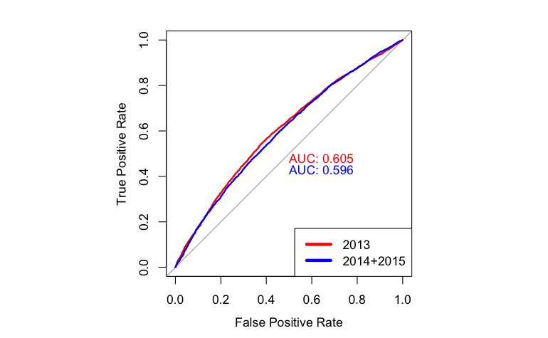

```r
legend("bottomright", legend=c("2013", "2014+2015"),
       col=c("red","blue"), lwd=4)
par(pty="m")
```